# Assignment-5

vivek rao kathheragandla

2024-04-01

Importing required libraries

```r
library("cluster")
library("caret")
library("factoextra")
```

#Import data set from local drive

```r
CEREALS<-read.csv("C:\\Users\\KATHHERAGANDLA VIVEK\\OneDrive\\Documents\\FML\\\\Assignment_5\\Cereals.csv")
```

#printing some records form the dataset

```r
head(CEREALS)
```

```
##                        name mfr type calories protein fat sodium fiber carbo
## 1                 100%_Bran   N    C       70       4   1    130  10.0   5.0
## 2         100%_Natural_Bran   Q    C      120       3   5     15   2.0   8.0
## 3                  All-Bran   K    C       70       4   1    260   9.0   7.0
## 4 All-Bran_with_Extra_Fiber   K    C       50       4   0    140  14.0   8.0
## 5            Almond_Delight   R    C      110       2   2    200   1.0  14.0
## 6   Apple_Cinnamon_Cheerios   G    C      110       2   2    180   1.5  10.5
##   sugars potass vitamins shelf weight cups   rating
## 1      6    280       25     3      1 0.33 68.40297
## 2      8    135        0     3      1 1.00 33.98368
## 3      5    320       25     3      1 0.33 59.42551
## 4      0    330       25     3      1 0.50 93.70491
## 5      8     NA       25     3      1 0.75 34.38484
## 6     10     70       25     1      1 0.75 29.50954
```

#printing the summary of the dataset

```r
summary(CEREALS)
```

```
##      name               mfr                type              calories
##  Length:77          Length:77          Length:77          Min.   : 50.0
##  Class :character   Class :character   Class :character   1st Qu.:100.0
##  Mode  :character   Mode  :character   Mode  :character   Median :110.0
##                                                           Mean   :106.9
##                                                           3rd Qu.:110.0
##                                                           Max.   :160.0
##
##     protein           fat            sodium          fiber
##  Min.   :1.000   Min.   :0.000   Min.   :  0.0   Min.   : 0.000
##  1st Qu.:2.000   1st Qu.:0.000   1st Qu.:130.0   1st Qu.: 1.000
##  Median :3.000   Median :1.000   Median :180.0   Median : 2.000
##  Mean   :2.545   Mean   :1.013   Mean   :159.7   Mean   : 2.152
##  3rd Qu.:3.000   3rd Qu.:2.000   3rd Qu.:210.0   3rd Qu.: 3.000
##  Max.   :6.000   Max.   :5.000   Max.   :320.0   Max.   :14.000
##
##      carbo          sugars           potass          vitamins
##  Min.   : 5.0   Min.   : 0.000   Min.   : 15.00   Min.   :  0.00
##  1st Qu.:12.0   1st Qu.: 3.000   1st Qu.: 42.50   1st Qu.: 25.00
##  Median :14.5   Median : 7.000   Median : 90.00   Median : 25.00
##  Mean   :14.8   Mean   : 7.026   Mean   : 98.67   Mean   : 28.25
##  3rd Qu.:17.0   3rd Qu.:11.000   3rd Qu.:120.00   3rd Qu.: 25.00
##  Max.   :23.0   Max.   :15.000   Max.   :330.00   Max.   :100.00
##  NA's   :1      NA's   :1        NA's   :2
##      shelf           weight          cups           rating
##  Min.   :1.000   Min.   :0.50   Min.   :0.250   Min.   :18.04
##  1st Qu.:1.000   1st Qu.:1.00   1st Qu.:0.670   1st Qu.:33.17
##  Median :2.000   Median :1.00   Median :0.750   Median :40.40
##  Mean   :2.208   Mean   :1.03   Mean   :0.821   Mean   :42.67
##  3rd Qu.:3.000   3rd Qu.:1.00   3rd Qu.:1.000   3rd Qu.:50.83
##  Max.   :3.000   Max.   :1.50   Max.   :1.500   Max.   :93.70
##
```

TASK-0 PRE-PROCESSING OF THE DATA

```r
#initializing a dataframe to store the pre-processsed data
cereal_scaled_data <- CEREALS
#scaling the cereals data and preparing for the clustering algorithm
cereal_scaled_data[ , c(4:16)] <- scale(CEREALS[ , c(4:16)])
#removing unwanted null values
cleansed_data <- na.omit(cereal_scaled_data)
#printing the pre-processed data
head(cleansed_data)
```

```
##                        name mfr type   calories    protein         fat
## 1                 100%_Bran   N    C -1.8929836  1.3286071 -0.01290349
## 2         100%_Natural_Bran   Q    C  0.6732089  0.4151897  3.96137277
## 3                  All-Bran   K    C -1.8929836  1.3286071 -0.01290349
## 4 All-Bran_with_Extra_Fiber   K    C -2.9194605  1.3286071 -1.00647256
## 6   Apple_Cinnamon_Cheerios   G    C  0.1599704 -0.4982277  0.98066557
## 7               Apple_Jacks   K    C  0.1599704 -0.4982277 -1.00647256
##       sodium       fiber      carbo     sugars     potass   vitamins      shelf
## 1 -0.3539844  3.29284661 -2.5087829 -0.2343906  2.5753685 -0.1453172  0.9515734
## 2 -1.7257708 -0.06375361 -1.7409943  0.2223705  0.5160205 -1.2642598  0.9515734
## 3  1.1967306  2.87327158 -1.9969238 -0.4627711  3.1434645 -0.1453172  0.9515734
## 4 -0.2346986  4.97114672 -1.7409943 -1.6046739  3.2854885 -0.1453172  0.9515734
## 6  0.2424445 -0.27354112 -1.1011705  0.6791317 -0.4071355 -0.1453172 -1.4507595
## 7 -0.4136273 -0.48332864 -0.9732057  1.5926539 -0.9752315 -0.1453172 -0.2495930
##       weight       cups     rating
## 1 -0.1967771 -2.1100340  1.8321876
## 2 -0.1967771  0.7690100 -0.6180571
## 3 -0.1967771 -2.1100340  1.1930986
## 4 -0.1967771 -1.3795303  3.6333849
## 6 -0.1967771 -0.3052601 -0.9365625
## 7 -0.1967771  0.7690100 -0.6756899
```

Following pre-processing, the data is sorted in an alphabetical order and, once the null values have been eliminated, has 74 records.

TASK 1 -

Apply hierarchical clustering to the data using Euclidean distance to the normalized measurements. Use Agnes to compare the clustering from single linkage, complete linkage, average linkage, and Ward. Choose the best method.

```r
#calculating the euclidean distance
Euclidean_dist<- dist(cleansed_data[ , c(4:16)], method = "euclidean")
#Euclidea_dist
```

APPLYING SINGLE LINKAGE

```r
#using AGNES to compare and single linkage method for clustering
clustering_H_single <- agnes(Euclidean_dist, method = "single")
```

Plotting the hierarchical clustering using single linkage method in a graph with Height on X-axis and cereal on Y-axis.

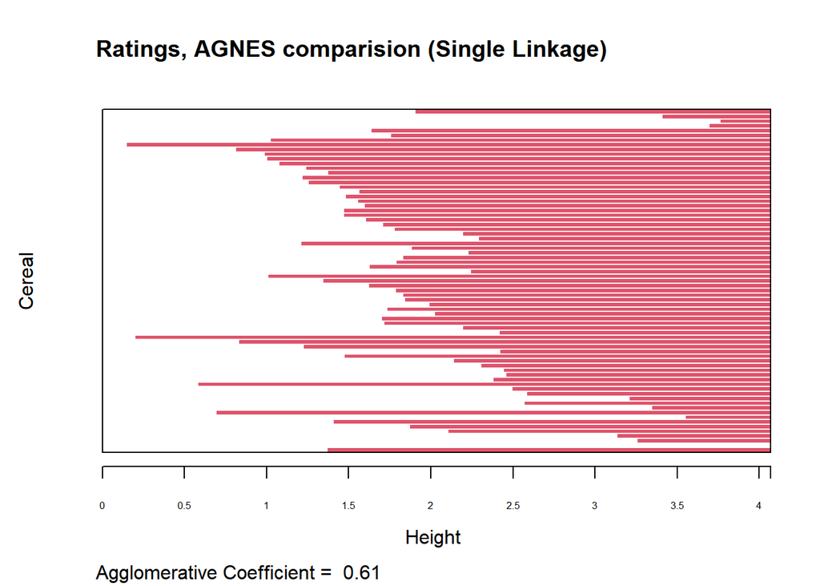

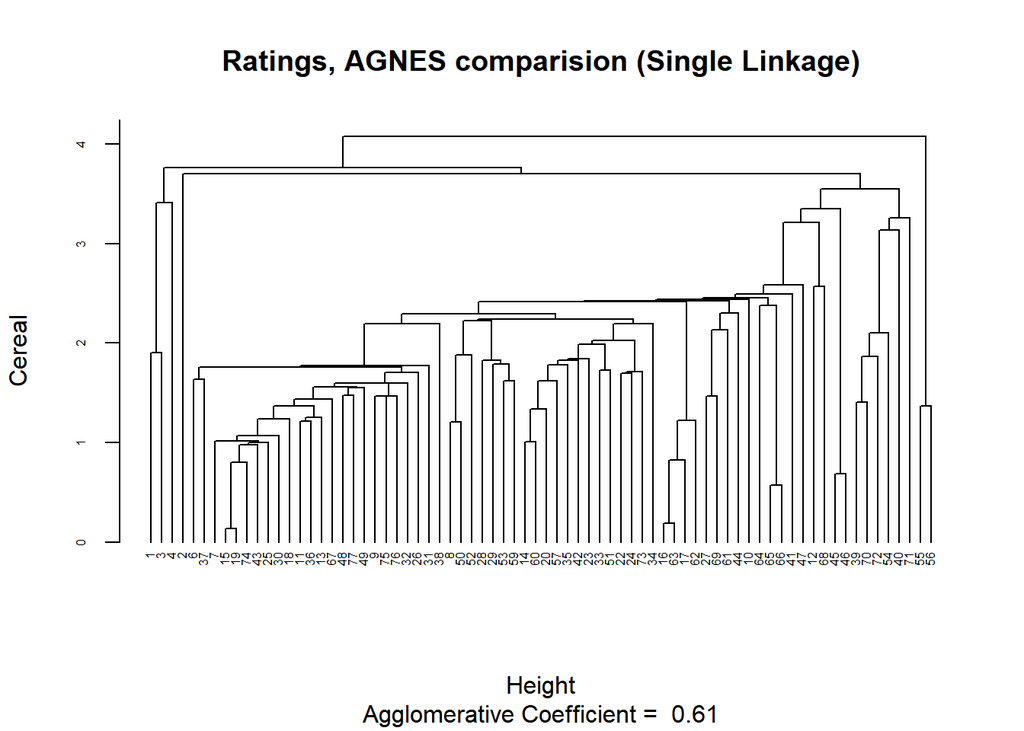

```r
plot(clustering_H_single,
main = "Ratings, AGNES comparision (Single Linkage)",
 xlab = "Height",
 ylab = "Cereal",
 cex.axis = 0.5,
 cex = 0.5,
 hang = -1)
```

```r
## Warning in plot.window(xlim, ylim, log = log, ...): "hang" is not a graphical
## parameter

## Warning in title(main = main, sub = sub, xlab = xlab, ylab = ylab, ...): "hang"
## is not a graphical parameter

## Warning in axis(1, at = at.vals, labels = lab.vals, ...): "hang" is not a
## graphical parameter
```

APPLYING COMPLETE LINKAGE

```r
#applying AGNES with complete linkage for clustering
clustering_H_complete <- agnes(Euclidean_dist, method = "complete")
```

plotting the clustering with complete linkage method

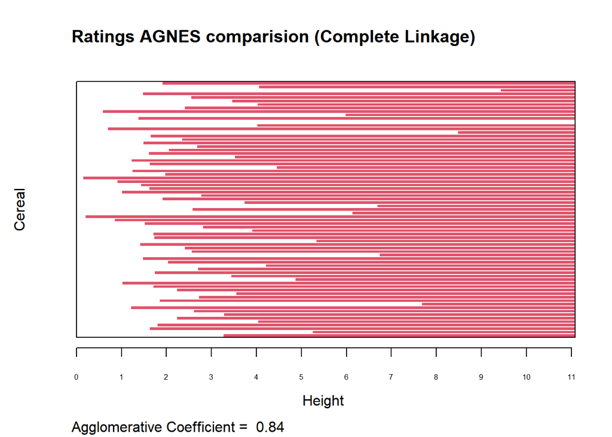

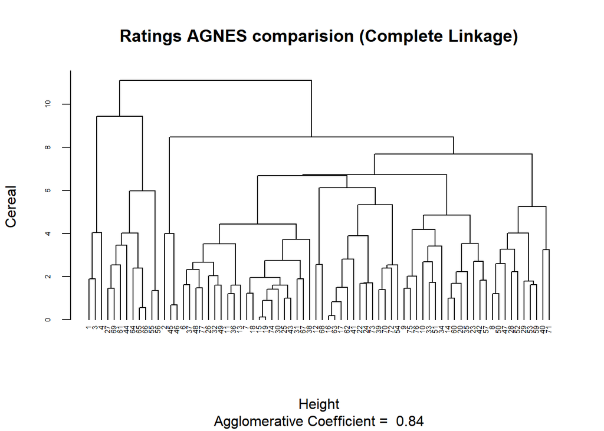

```r
plot(clustering_H_complete,
 main = "Ratings AGNES comparision (Complete Linkage)",
 xlab = "Height",
 ylab = "Cereal",
 cex.axis = 0.5,
 cex = 0.50,
 hang = -1)
```

```r
## Warning in plot.window(xlim, ylim, log = log, ...): "hang" is not a graphical
## parameter

## Warning in title(main = main, sub = sub, xlab = xlab, ylab = ylab, ...): "hang"
## is not a graphical parameter

## Warning in axis(1, at = at.vals, labels = lab.vals, ...): "hang" is not a
## graphical parameter
```

AVERAGE LINKAGE METHOD

```r
#applying AGNES with Average linkage method
clustering_H_average <- agnes(Euclidean_dist, method = "average")
```

PLOTTING THE AGNES comparison with Average linkage method

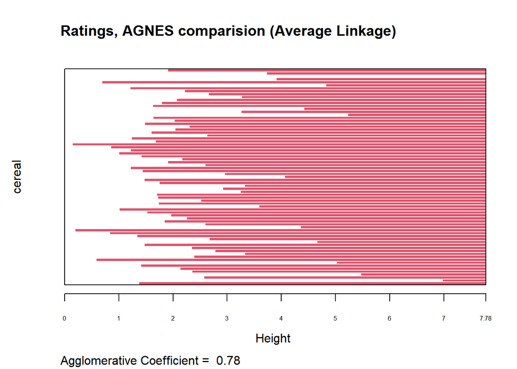

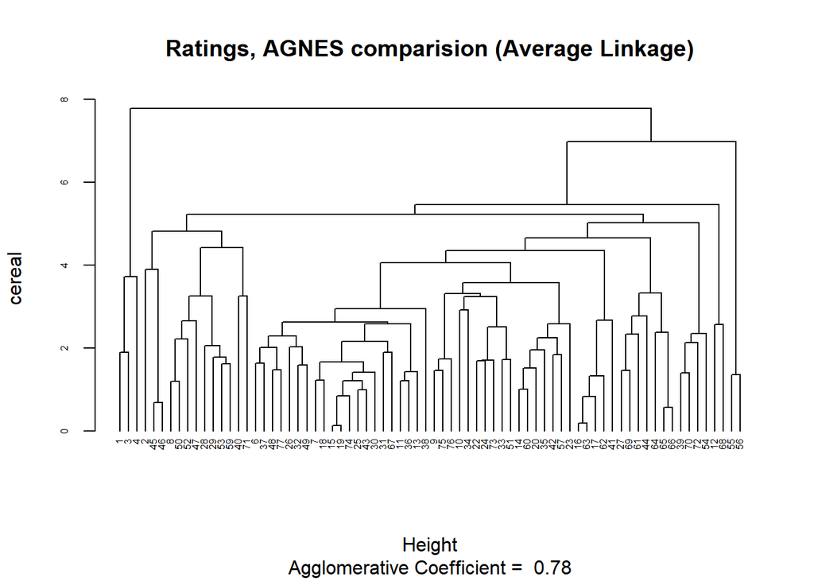

```r
plot(clustering_H_average,
 main = "Ratings, AGNES comparision (Average Linkage)",
 xlab = "Height",
 ylab = "cereal",
 cex.axis = 0.5,
 cex = 0.50,
 hang = -1)
```

```r
## Warning in plot.window(xlim, ylim, log = log, ...): "hang" is not a graphical
## parameter

## Warning in title(main = main, sub = sub, xlab = xlab, ylab = ylab, ...): "hang"
## is not a graphical parameter

## Warning in axis(1, at = at.vals, labels = lab.vals, ...): "hang" is not a
## graphical parameter
```

PERFORMING WARD LINKAGE METHOD

```r
clustering_H_WARD <- agnes(Euclidean_dist, method = "ward")
```

PLOTTING THE RESULTS AFTER USING WARD LINKAGE METHOD

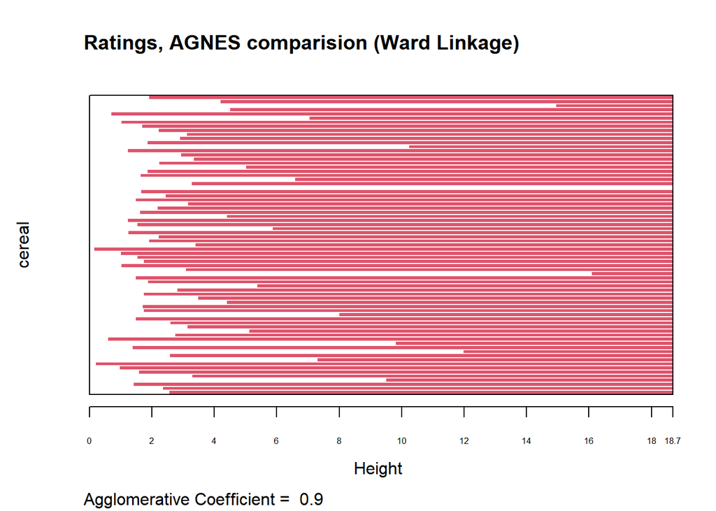

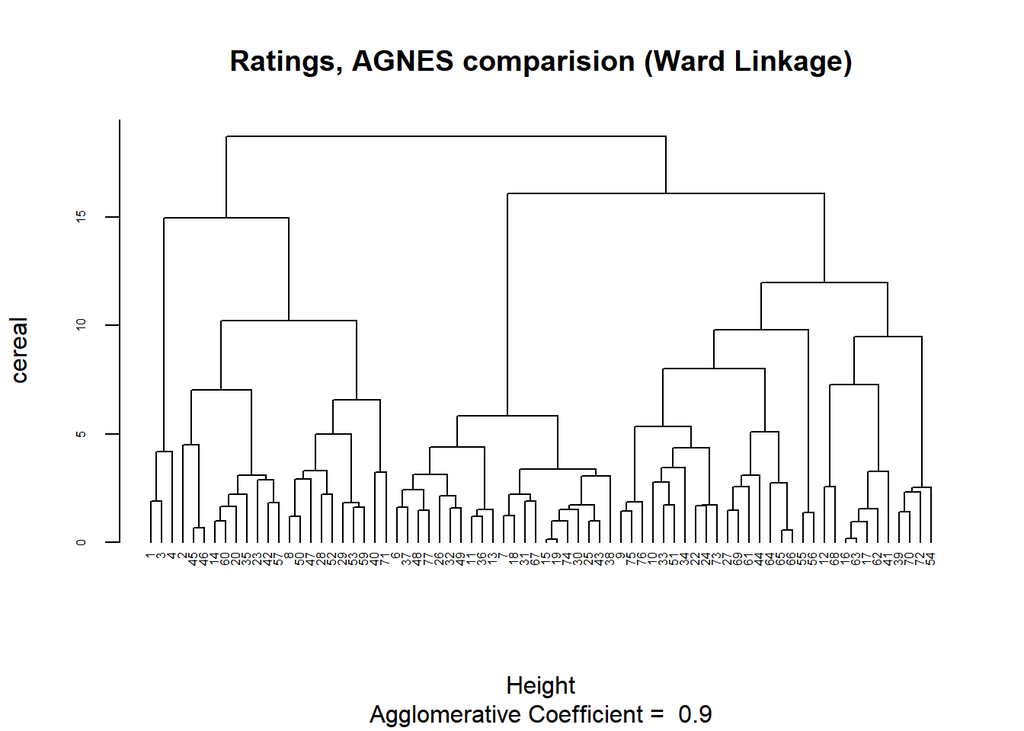

```r
plot(clustering_H_WARD,
 main = "Ratings, AGNES comparision (Ward Linkage)",
 xlab = "Height",
 ylab = "cereal",
 cex.axis = 0.5,
 cex = 0.50,
 hang = -1)
```

```r
## Warning in plot.window(xlim, ylim, log = log, ...): "hang" is not a graphical
## parameter

## Warning in title(main = main, sub = sub, xlab = xlab, ylab = ylab, ...): "hang"
## is not a graphical parameter

## Warning in axis(1, at = at.vals, labels = lab.vals, ...): "hang" is not a
## graphical parameter
```

After applying all the linkage methods with AGNES we found the observations as Single Linkage method: 0.61 Complete Linkage method: 0.84 Average Linkage method: 0.78 Ward Method method: 0.90 Here we can conclude that, the ward method with highest Agglomerative coefficient will be better suited for this clustering.

TASK-2

How many clusters would you choose? Figuring out the optimal of clusters we can make with this data. Applying silhoutte method to figure out the number of optimal clusters.

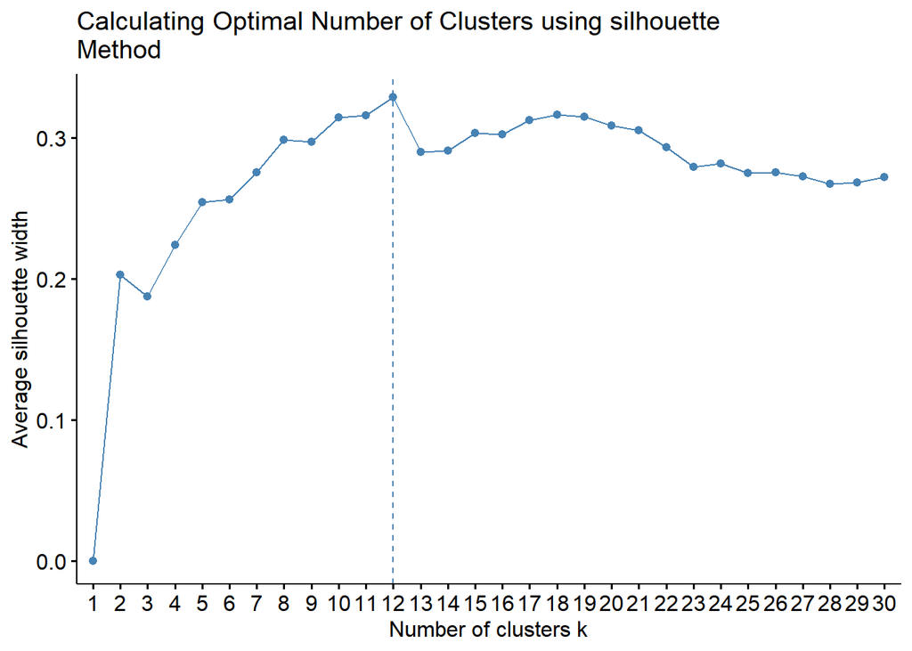

```r
# Calculate the optimal number of clusters for the dataset using the withincluster sum of squares (WCSS) method
# using the fviz_nbclust() function from the factoextra package
fviz_nbclust(cleansed_data[ , c(4:16)], hcut, method = "silhouette", k.max =
30) +
 labs(title = "Calculating Optimal Number of Clusters using silhouette
Method")
```

Applying Elbow method to figure out the number of optimal clusters.

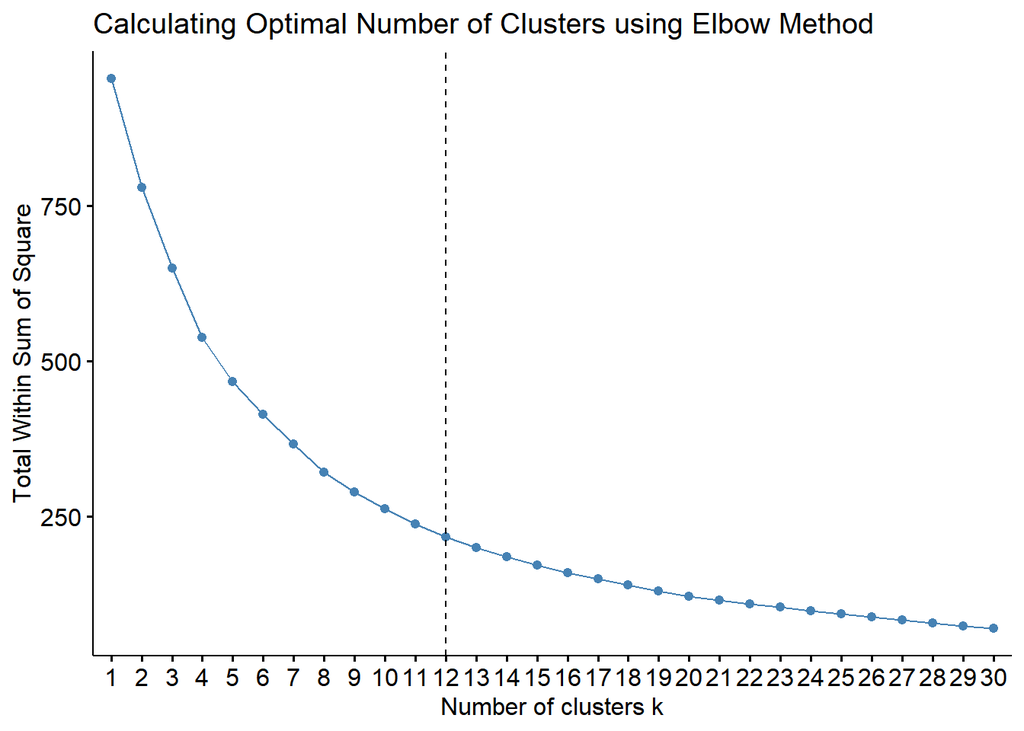

```r
# Determine the optimal number of clusters for the dataset using the Elbow method
fviz_nbclust(cleansed_data[ , c(4:16)], hcut, method = "wss", k.max = 30) +
 labs(title = "Calculating Optimal Number of Clusters using Elbow Method") +
 geom_vline(xintercept = 12, linetype = 2)
```

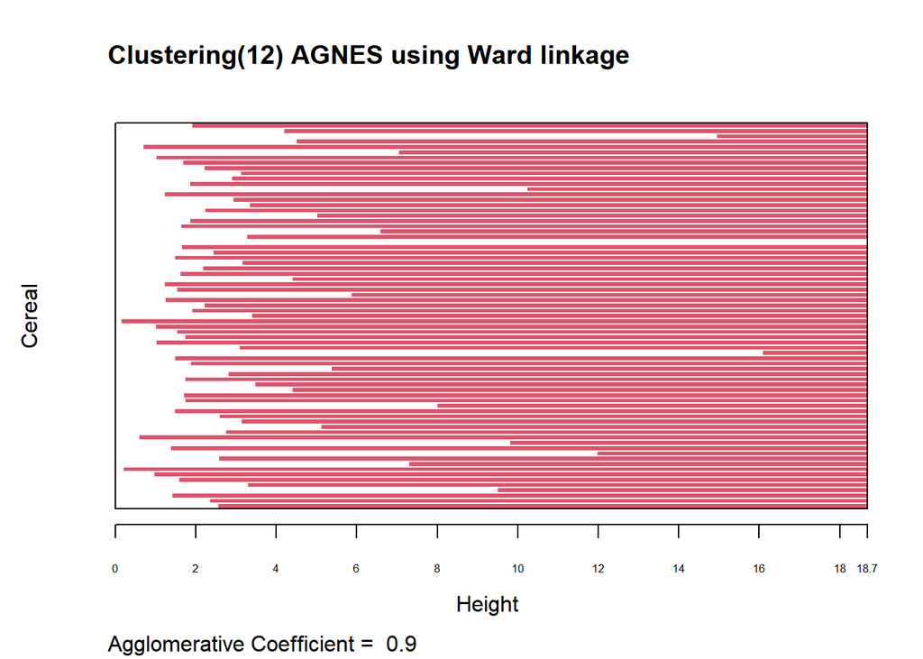

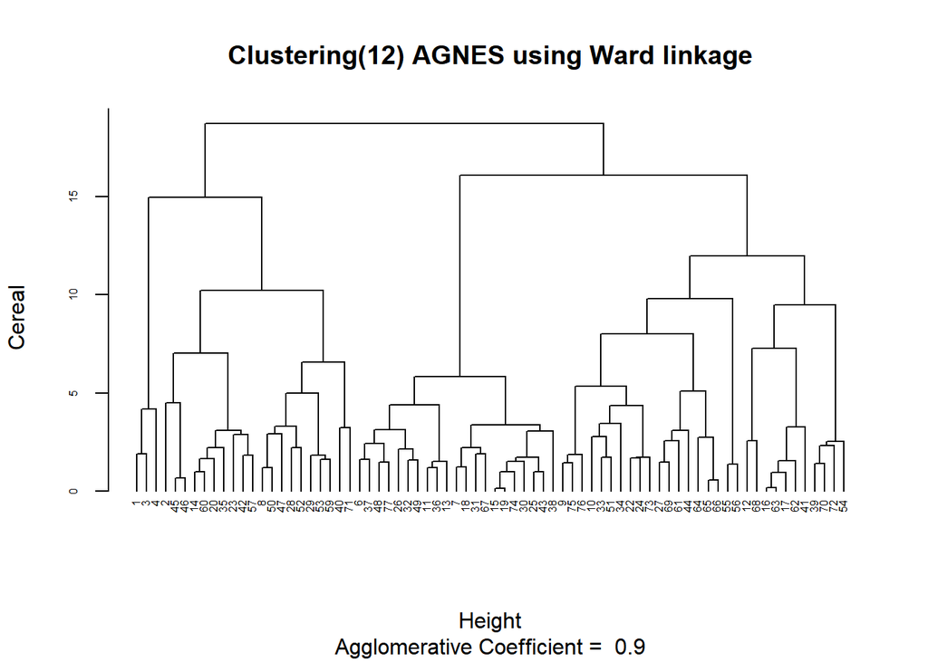

```r
plot(clustering_H_WARD,
 main = "Clustering(12) AGNES using Ward linkage",
 xlab = "Height",
 ylab = "Cereal",
 cex.axis = 0.5,
 cex = 0.50,
 hang = -1)
```

```r
## Warning in plot.window(xlim, ylim, log = log, ...): "hang" is not a graphical
## parameter

## Warning in title(main = main, sub = sub, xlab = xlab, ylab = ylab, ...): "hang"
## is not a graphical parameter

## Warning in axis(1, at = at.vals, labels = lab.vals, ...): "hang" is not a
## graphical parameter
```

Hence, the cereal data may be optimally grouped into 12 clusters using AGNE’s ward linkage approach, with an agglomerative coefficent of about 0.9 for hierarchical clustering.